# Assignment 10: Predictive Modeling - Part 1

*How to do it?*:

- Open the Rmarkdown file of this assignment (link) in Rstudio.
- Right under each **question**, insert a code chunk (you can use the hotkey `Ctrl + Alt + I` to add a code chunk) and code the solution for the question.
- `Knit` the rmarkdown file (hotkey: `Ctrl + Alt + K`) to export an html.
- Publish the html file to your Githiub Page.

*Submission*: Submit the link on Github of the assignment to Canvas

1. Use the `Adult Census Income` dataset. We will predict the income (whether or not it is more than 50k or not) of an adult. Import the dataset. Partition the data into 80% training and 20% testing.

```r
library(tidyverse)
library(rattle)
library(rpart)
library(randomForest)
library(caret)
library(caTools)
df <- read.csv("adult_census_missing.csv")
```

```r
df <- na.omit(df)
df$income <- factor(df$income, levels = c("<=50K", ">50K"))
```

```r
set.seed(123)
split <- sample.split(df$income, SplitRatio = 0.8)
train <- subset(df, split == TRUE)
test <- subset(df, split == FALSE)
```

2. Practice Decision Tree. Do the follows:
- Use `rpart` package, create a decision tree with maximum depth of 3.
- Calculate the accuracy of the model on the testing data. Notice that the positive outcome here is not `1` but `>50K` or `<50K`.
- Plot the tree
- Plot the variable importance by the tree

```r
tree1 <- rpart(income ~ ., data = train, method = "class", control = rpart.control(maxdepth = 3))
pred_tree1 <- predict(tree1, test, type = "class")
accuracy_tree1 <- sum(pred_tree1 == test$income) / nrow(test)
print(paste("Decision Tree (Depth=3) Accuracy:", round(accuracy_tree1, 4)))
```

```
## [1] "Decision Tree (Depth=3) Accuracy: 0.8429"
```

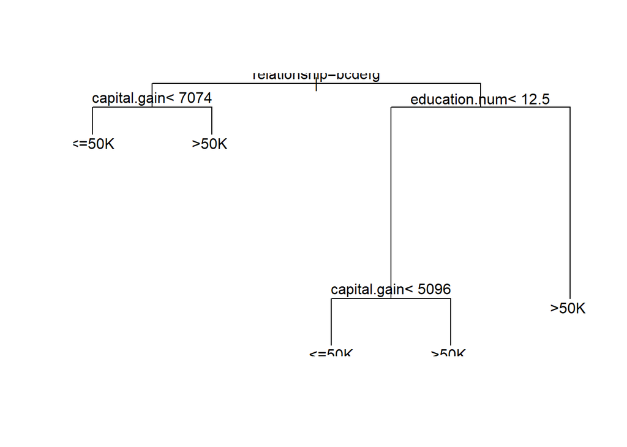

```r
plot(tree1)
text(tree1)
```

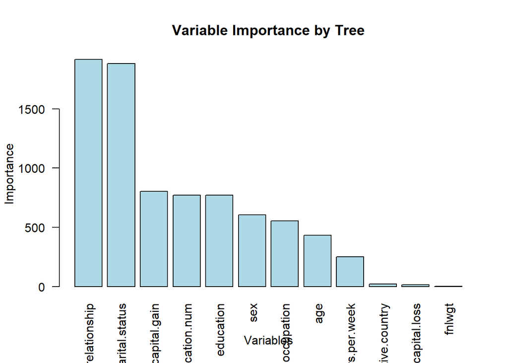

```r
var_importance_tree <- tree1$variable.importance
barplot(var_importance_tree,
        main = "Variable Importance by Tree",
        xlab = "Variables",
        ylab = "Importance",
        col = "lightblue",
        las = 2)
```

3. Create 3 more trees and compare the testing accuracy of these trees, which tree give the highest testing accuracy.

```r
tree2 <- rpart(income ~ ., data = train, method = "class", control = rpart.control(maxdepth = 5))
pred_tree2 <- predict(tree2, test, type = "class")
accuracy_tree2 <- sum(pred_tree2 == test$income) / nrow(test)
```

```r
tree3 <- rpart(income ~ ., data = train, method = "class", control = rpart.control(minsplit = 20))
pred_tree3 <- predict(tree3, test, type = "class")
accuracy_tree3 <- sum(pred_tree3 == test$income) / nrow(test)
```

```r
tree4 <- rpart(income ~ ., data = train, method = "class", control = rpart.control(cp = 0.01))
pred_tree4 <- predict(tree4, test, type = "class")
accuracy_tree4 <- sum(pred_tree4 == test$income) / nrow(test)
```

```r
tree_accuracies <- c(accuracy_tree1, accuracy_tree2, accuracy_tree3, accuracy_tree4)
names(tree_accuracies) <- c("Tree1", "Tree2", "Tree3", "Tree4")
print(tree_accuracies)
```

```
##     Tree1     Tree2     Tree3     Tree4
## 0.8428901 0.8428901 0.8428901 0.8428901
```

4. Practice Random Forest. Do the follows:
- Use `randomForest` package, create a random forest of 1000 trees.
- Calculate the accuracy of the model on the testing data.
- Plot the variable importance by the forest

```r
rf1 <- randomForest(income ~ ., data = train, ntree = 1000)
pred_rf1 <- predict(rf1, test)
accuracy_rf1 <- sum(pred_rf1 == test$income) / nrow(test)
print(paste("Random Forest (1000 Trees) Accuracy:", round(accuracy_rf1, 4)))
```

```
## [1] "Random Forest (1000 Trees) Accuracy: 0.8598"
```

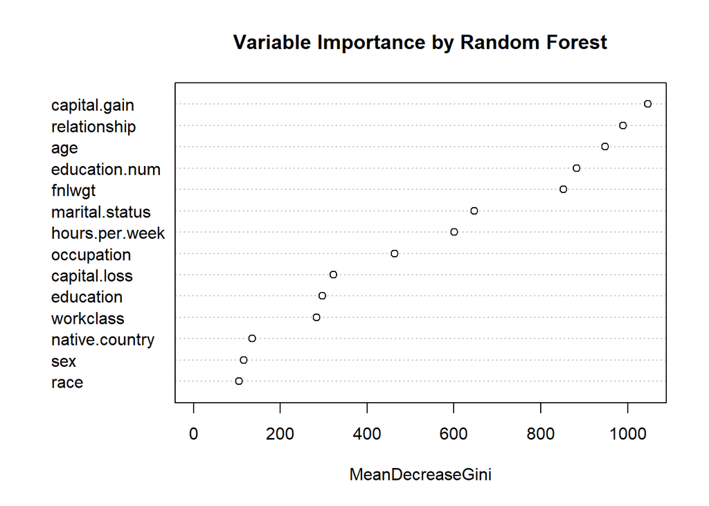

```r
varImpPlot(rf1, main = "Variable Importance by Random Forest")
```

5. Create 3 more forests and compare the testing accuracy of these forests, which forest give the highest testing accuracy.

```r
library(randomForest)

rf2 <- randomForest(income ~ ., data = train, ntree = 500)
pred_rf2 <- predict(rf2, test)
accuracy_rf2 <- sum(pred_rf2 == test$income) / nrow(test)
```

```r
rf3 <- randomForest(income ~ ., data = train, ntree = 1500)
pred_rf3 <- predict(rf3, test)
accuracy_rf3 <- sum(pred_rf3 == test$income) / nrow(test)
```

```r
rf4 <- randomForest(income ~ ., data = train, ntree = 1000, mtry = 3)
pred_rf4 <- predict(rf4, test)
accuracy_rf4 <- sum(pred_rf4 == test$income) / nrow(test)
```

```r
forest_accuracies <- c(accuracy_rf1, accuracy_rf2, accuracy_rf3, accuracy_rf4)
names(forest_accuracies) <- c("RF1 (1000 trees)", "RF2 (500 trees)", "RF3 (1500 trees)", "RF4 (mtry=3)")
print("Testing Accuracies of Random Forests:")
```

```
## [1] "Testing Accuracies of Random Forests:"
```

```r
print(forest_accuracies)
```

```
## RF1 (1000 trees)  RF2 (500 trees) RF3 (1500 trees)     RF4 (mtry=3)
##        0.8598002        0.8582629        0.8579554        0.8588778
```

6. What is the best model (in term of testing accuracy) among all models (including trees and forests) you have trained?

```r
best_forest <- names(forest_accuracies)[which.max(forest_accuracies)]
best_accuracy <- max(forest_accuracies)

cat("The best random forest model is", best_forest, "with an accuracy of", round(best_accuracy, 4), "\n")
```

```
## The best random forest model is RF1 (1000 trees) with an accuracy of 0.8598
```